# CEE 218 HW 1

## Combining Data for Years 2017 to 2020: Electricity

```r
years <- c(2017,2018,2019,2020)
quarters <- 1:4
type <- "Electric"
filename <- '0'

pge_17to20elec <- NULL

for(year in years) {

  for(quarter in quarters) {

    if (year == 2020 & quarter == (3)){
      break
      }

      filename <-
      paste0(
      "PGE_",
      year,
      "_Q",
      quarter,
      "_",
      type,
      "UsageByZip.csv")

      print(filename)

      temp <- read_csv(filename)

      pge_17to20elec <- rbind(pge_17to20elec,temp)
    # Note rbind requires field names to be consistent for every new thing that you add.

      saveRDS(pge_17to20elec, "pge_17to20elec.rds")
  }
}
```

```
## [1] "PGE_2017_Q1_ElectricUsageByZip.csv"
## [1] "PGE_2017_Q2_ElectricUsageByZip.csv"
## [1] "PGE_2017_Q3_ElectricUsageByZip.csv"
## [1] "PGE_2017_Q4_ElectricUsageByZip.csv"
## [1] "PGE_2018_Q1_ElectricUsageByZip.csv"
## [1] "PGE_2018_Q2_ElectricUsageByZip.csv"
## [1] "PGE_2018_Q3_ElectricUsageByZip.csv"
## [1] "PGE_2018_Q4_ElectricUsageByZip.csv"
## [1] "PGE_2019_Q1_ElectricUsageByZip.csv"
## [1] "PGE_2019_Q2_ElectricUsageByZip.csv"
## [1] "PGE_2019_Q3_ElectricUsageByZip.csv"
## [1] "PGE_2019_Q4_ElectricUsageByZip.csv"
## [1] "PGE_2020_Q1_ElectricUsageByZip.csv"
## [1] "PGE_2020_Q2_ElectricUsageByZip.csv"
```

## Combining Data for Years 2017 to 2020: Gas

```r
years <- c(2017,2018,2019,2020)
quarters <- 1:4
type2 <- "Gas"

pge_17to20gas <- NULL

for(year in years) {

  for(quarter in quarters) {

     if (year == 2020 & quarter == (3)){
      break
      }

    filename <-
      paste0(
        "PGE_",
        year,
        "_Q",
        quarter,
        "_",
        type2,
        "UsageByZip.csv"
      )

    print(filename)

    temp2 <- read_csv(filename)

    pge_17to20gas <- rbind(pge_17to20gas,temp2)
    # Note rbind requires field names to be consistent for every new thing that you add.

    saveRDS(pge_17to20gas, "pge_17to20gas.rds")
  }
}
```

```
## [1] "PGE_2017_Q1_GasUsageByZip.csv"
## [1] "PGE_2017_Q2_GasUsageByZip.csv"
## [1] "PGE_2017_Q3_GasUsageByZip.csv"
## [1] "PGE_2017_Q4_GasUsageByZip.csv"
## [1] "PGE_2018_Q1_GasUsageByZip.csv"
## [1] "PGE_2018_Q2_GasUsageByZip.csv"
## [1] "PGE_2018_Q3_GasUsageByZip.csv"
## [1] "PGE_2018_Q4_GasUsageByZip.csv"
## [1] "PGE_2019_Q1_GasUsageByZip.csv"
## [1] "PGE_2019_Q2_GasUsageByZip.csv"
## [1] "PGE_2019_Q3_GasUsageByZip.csv"
## [1] "PGE_2019_Q4_GasUsageByZip.csv"
## [1] "PGE_2020_Q1_GasUsageByZip.csv"
## [1] "PGE_2020_Q2_GasUsageByZip.csv"
```

## Filter Residential and Commercial Data and Group: Electricity

```r
pge_final_elec <-
  pge_17to20elec %>%
  filter(
    CUSTOMERCLASS %in%
      c(
        "Elec- Residential",
        "Elec- Commercial"
      )
  ) %>%
  select(
    !c(COMBINED, AVERAGEKWH)
  ) %>%
  group_by(YEAR,MONTH, CUSTOMERCLASS) %>%
  summarize(
    TOTALKWH =
      sum(
        TOTALKWH,
        na.rm = T
      ),
    TOTALCUSTOMERS =
      sum(
        TOTALCUSTOMERS,
        na.rm = T
      )
  ) %>%
  mutate(
    AVERAGEKWH =
      TOTALKWH/TOTALCUSTOMERS
  )

pge_final_elec
```

```
## # A tibble: 84 x 6
## # Groups:   YEAR, MONTH [42]
##     YEAR MONTH CUSTOMERCLASS       TOTALKWH TOTALCUSTOMERS AVERAGEKWH
##    <dbl> <dbl> <chr>                  <dbl>          <dbl>      <dbl>
##  1  2017     1 Elec- Commercial  2518133184         312242      8065.
##  2  2017     1 Elec- Residential 2696632298        4427009       609.
##  3  2017     2 Elec- Commercial  2186409895         312327      7000.
##  4  2017     2 Elec- Residential 2089405296        4429320       472.
##  5  2017     3 Elec- Commercial  2328765919         312586      7450.
##  6  2017     3 Elec- Residential 2007875145        4432096       453.
##  7  2017     4 Elec- Commercial  2260528589         313499      7211.
##  8  2017     4 Elec- Residential 1838107707        4437095       414.
##  9  2017     5 Elec- Commercial  2472760712         313795      7880.
## 10  2017     5 Elec- Residential 2070656073        4438946       466.
## # ... with 74 more rows
```

## Filter Residential and Commercial Data and Group: Gas

```r
pge_final_gas <-
  pge_17to20gas %>%
  filter(
    CUSTOMERCLASS %in%
      c(
        "Gas- Residential",
        "Gas- Commercial"
      )
  ) %>%
  select(
    !c(COMBINED, AVERAGETHM)
  ) %>%
  group_by(YEAR,MONTH, CUSTOMERCLASS) %>%
  summarize(
    TOTALTHM =
      sum(
        TOTALTHM,
        na.rm = T
      ),
    TOTALCUSTOMERS =
      sum(
        TOTALCUSTOMERS,
        na.rm = T
      )
  ) %>%
  mutate(
    AVERAGETHM =
      TOTALTHM/TOTALCUSTOMERS
  )

pge_final_gas
```

```
## # A tibble: 84 x 6
## # Groups:   YEAR, MONTH [42]
##     YEAR MONTH CUSTOMERCLASS     TOTALTHM TOTALCUSTOMERS AVERAGETHM
##    <dbl> <dbl> <chr>                <dbl>          <dbl>      <dbl>
##  1  2017     1 Gas- Commercial   81974539         173036      474.
##  2  2017     1 Gas- Residential 332986863        4059858       82.0
##  3  2017     2 Gas- Commercial   57175524         173096      330.
##  4  2017     2 Gas- Residential 214756795        4062740       52.9
##  5  2017     3 Gas- Commercial   51732816         173061      299.
##  6  2017     3 Gas- Residential 167698331        4065227       41.3
##  7  2017     4 Gas- Commercial   42328501         172695      245.
##  8  2017     4 Gas- Residential 128910844        4069161       31.7
##  9  2017     5 Gas- Commercial   36825348         172309      214.
## 10  2017     5 Gas- Residential  93587412        4069311       23.0
## # ... with 74 more rows
```

## Converting Units (KWH’s and Therms) to kBTUs

```r
elec_kbtu <- (pge_final_elec$TOTALKWH)*3.41214
pge_final_elec$TOTALKBTU <- with(pge_final_elec,elec_kbtu)

gas_kbtu <- (pge_final_gas$TOTALTHM)*100
pge_final_gas$TOTALKBTU <- with(pge_final_gas,gas_kbtu)
```

## Line Chart of Energy Consumption for Residential and Commercial in KBTUs Over Time

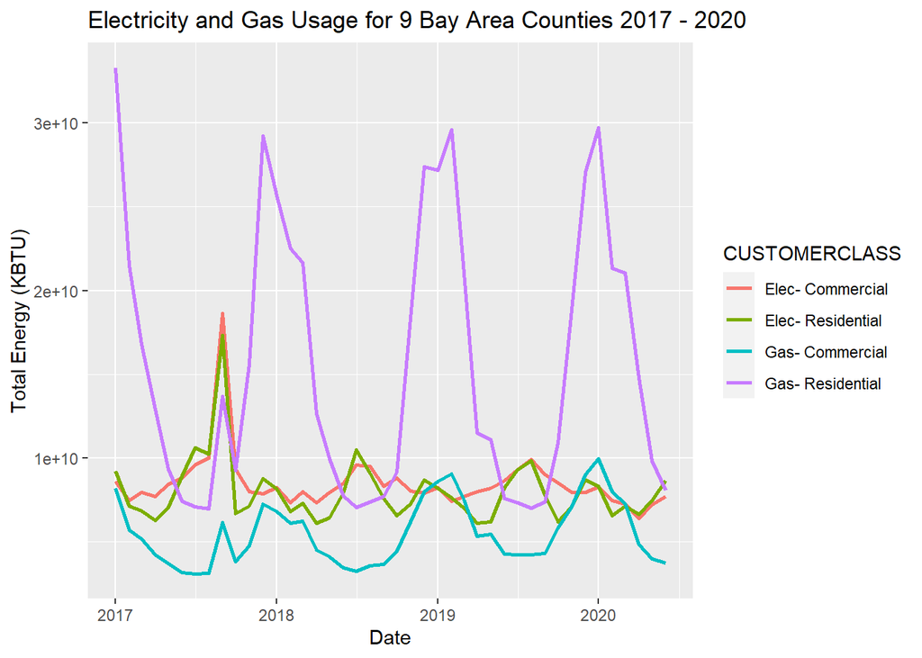

```r
library(dplyr)
elec_res <- filter(pge_final_elec,
                   CUSTOMERCLASS == "Elec- Residential")
elec_com <- filter(pge_final_elec,
                   CUSTOMERCLASS == "Elec- Commercial")
gas_res <- filter(pge_final_gas,
                   CUSTOMERCLASS == "Gas- Residential")
gas_com <- filter(pge_final_gas,
                   CUSTOMERCLASS == "Gas- Commercial")

both_matrix <-
  rbind(elec_res,elec_com) %>%
  rbind(gas_res) %>%
  rbind(gas_com) %>%
  mutate('Date'= paste(sep = '-',YEAR,MONTH,'01') %>% as.Date())


ggplot(both_matrix, aes(x=Date, y=TOTALKBTU, group=CUSTOMERCLASS, color=CUSTOMERCLASS)) +
  ylab("Total Energy (KBTU)")+ggtitle("Electricity and Gas Usage for 9 Bay Area Counties 2017 - 2020")+
  geom_line(size=1)
```

## Seperating Bay Area Counties and Creating Block Groups

```r
ca_counties <- counties("CA", cb = T, progress_bar = F)

bay_county_names <-
  c(
    "Alameda",
    "Contra Costa",
    "Marin",
    "Napa",
    "San Francisco",
    "San Mateo",
    "Santa Clara",
    "Solano",
    "Sonoma"
  )

bay_counties <-
  ca_counties %>%
  filter(NAME %in% bay_county_names)

ca_cities <- places("CA", cb = T, progress_bar = FALSE)

bay_cities <- ca_cities[bay_counties, ]

bay_cities_within <-
  ca_cities %>%
  st_centroid() %>%
  .[bay_counties, ] %>%
  st_set_geometry(NULL) %>%
  left_join(ca_cities %>% select(GEOID)) %>%
  st_as_sf()

bay_cities_within <-
  ca_cities[which(ca_cities$GEOID %in% st_centroid(ca_cities)[bay_counties, ]$GEOID), ]

bay_cbgs <- block_groups("CA", bay_county_names[1:9], cb = T, progress_bar = F)

bay_cbgs <-
  bay_county_names %>%
  map_dfr(function(county) {
    block_groups("CA", county, cb = T, progress_bar = F)
  })

bay_cbgs_clip <- st_read("https://opendata.arcgis.com/datasets/037fc1597b5a4c6994b89c46a8fb4f06_0.geojson")
```

## Mapping the Percentage Change in Residential Electricty Use for Bay Area Counties Due To Covid-19

### The data used for this process is the 2nd quarter electricty data (April, May, June) from 2019 and 2020

```r
elec_q2_2019 <- read_csv("PGE_2019_Q2_ElectricUsageByZip.csv")
elec_q2_2020 <- read_csv("PGE_2020_Q2_ElectricUsageByZip.csv")

usa_zips <-
  zctas(cb = T, progress_bar = F)

bay_zips <-
  usa_zips %>%
  st_centroid() %>%
  .[bay_counties, ] %>%
  st_set_geometry(NULL) %>%
  left_join(usa_zips %>% select(GEOID10)) %>%
  st_as_sf()

elec_2019 <-
  elec_q2_2019 %>%
  filter(CUSTOMERCLASS %in%
      c(
        "Elec- Residential")
      ) %>%
  mutate(
    ZIPCODE = ZIPCODE %>% as.character()
  ) %>%
   mutate(
    TOTALKWH =TOTALKWH %>% as.numeric()
  ) %>%
  na.omit() %>%
  group_by(ZIPCODE) %>%
  summarize(
    TOTALKWH = sum(TOTALKWH, na.rm = T)
  ) %>%
  right_join(
    bay_zips %>% select(GEOID10),
    by = c("ZIPCODE" = "GEOID10")
  ) %>%
  st_as_sf() %>%
  st_transform(4326)


elec_2020 <-
  elec_q2_2020 %>%
   filter(CUSTOMERCLASS %in%
      c(
        "Elec- Residential")
      ) %>%
  mutate(
    ZIPCODE = ZIPCODE %>% as.character()
  ) %>%
  na.omit() %>%
  group_by(ZIPCODE) %>%
  summarize(
    TOTALKWH = sum(TOTALKWH, na.rm = T)
  ) %>%
  right_join(
    bay_zips %>% select(GEOID10),
    by = c("ZIPCODE" = "GEOID10")
  ) %>%
  st_as_sf() %>%
  st_transform(4326)

elec_2019$Difference <- elec_2020$TOTALKWH-elec_2019$TOTALKWH
elec_2019$Perc_Difference<- (elec_2019$Difference/elec_2019$TOTALKWH)*100
elec_2019 %>% na.omit()
```

```
## Simple feature collection with 267 features and 4 fields
## geometry type:  MULTIPOLYGON
## dimension:      XY
## bbox:           xmin: -123.5335 ymin: 36.89303 xmax: -121.3083 ymax: 38.93713
## geographic CRS: WGS 84
## # A tibble: 267 x 5
##    ZIPCODE TOTALKWH                          geometry Difference Perc_Difference
##    <chr>      <dbl>                <MULTIPOLYGON [°]>      <dbl>           <dbl>
##  1 94002   11509871 (((-122.3359 37.50805, -122.3302~     989762            8.60
##  2 94005    1902800 (((-122.442 37.69435, -122.44 37~     209684           11.0
##  3 94010   25333124 (((-122.4126 37.58916, -122.4107~    1887709            7.45
##  4 94014   14941727 (((-122.4718 37.70225, -122.4711~    1709658           11.4
##  5 94015   19698995 (((-122.4983 37.70813, -122.4715~    2118199           10.8
##  6 94019    6423860 (((-122.5113 37.52301, -122.5087~     182404            2.84
##  7 94020    1119392 (((-122.3284 37.3143, -122.3271 ~      62868            5.62
##  8 94022   14997337 (((-122.1855 37.32374, -122.183 ~    1241514            8.28
##  9 94024   13957728 (((-122.1416 37.34951, -122.1367~    1124564            8.06
## 10 94025   21122047 (((-122.2291 37.4243, -122.2252 ~    2170281           10.3
## # ... with 257 more rows
```

```r
elec_2019 <- elec_2019[which(elec_2019$Perc_Difference > -40), ]
```

## Map of the Change in Residential Electricity Consumption Due to Covid-19

### In the map below we can see the percentage change of electricty consumption for residential buildings to determine the possible effects of Covid-19. For this analysis we compare the total electricity consumption for each zipcode in the Bay Area for the months of April, May, and June of 2019 and 2020. We compared these two time frames so as to eliminate confounding factors such as seasonl weather, which could mask the effects of Covid. Furthermore we picked the months of April, May and June because that is when the infection rate of Covid was highest as well as when the major social distancing policies were put into place. In the map below we can see that most of the zipcodes had a 5 to 20% increase in resdiential electricity consumption with only a handful showing decreases in electricity consumption. For the sake of creating a clearer visualization we also removed one outlier which showed a zipcode with -73% residential electricity consumption for the given period.

```r
res_pal <- colorNumeric(
  palette = "RdYlBu",
  domain =
    elec_2019$Perc_Difference
)

leaflet() %>%
  addTiles() %>%
  addPolygons(
    data = elec_2019,
    fillColor = ~res_pal(Perc_Difference),
    color = "white",
    opacity = 0.9,
    fillOpacity = 0.9,
    weight = 1,
    label = ~paste0(
      round(Perc_Difference),
      " kWh total in ",
      ZIPCODE
    ),
    highlightOptions = highlightOptions(
      weight = 2,
      opacity = 1
    )
  ) %>%
  addLegend(
    data = elec_2019,
    pal = res_pal,
    values = ~Perc_Difference,
    title = "Total Residential Percentage Difference<br> between Q2 of 2019 and Q2 of 2020"
  )
```

[interactive chart not shown]